# Ejemplos RLM

Author

Jorge de la Vega

Published

January 4, 2022

## Ejemplos de estimación en RLM

Algunos paquetes en R que se especializan en temas de regresión:

- `car`
- `alr4`

### Ejemplo 1: Prestigio ocupacional

El conjunto de datos `Prestige` en el paquete `car` contiene datos sobre 102 ocupaciones con los siguientes datos asociados:

- `education`: número promedio de años de educación de acuerdo al Censo de Canadá.
- `income`: ingreso promedio de las ocupaciones, en CAD.
- `women`: porcentaje de mujeres en esa profesión en el Censo que eran mujeres
- `prestige`: La calificación promedio del prestigio de la ocupación obtenida en base a una encuesta
- `census`: Código de la ocupación en la clasificación estándar del Censo de Canadá.
- `type`: Clasificación: profesional y gerencial (`prof`), cuello blanco (`wc`), cuello azul (`bc`) o faltante (`NA`).

```r
library(car)
data("Prestige")
head(Prestige)
```

```
                    education income women prestige census type
gov.administrators      13.11  12351 11.16     68.8   1113 prof
general.managers        12.26  25879  4.02     69.1   1130 prof
accountants             12.77   9271 15.70     63.4   1171 prof
purchasing.officers     11.42   8865  9.11     56.8   1175 prof
chemists                14.62   8403 11.68     73.5   2111 prof
physicists              15.64  11030  5.13     77.6   2113 prof
```

```r
summary(Prestige)
```

```
   education          income          women           prestige         census       type
 Min.   : 6.380   Min.   :  611   Min.   : 0.000   Min.   :14.80   Min.   :1113   bc  :44
 1st Qu.: 8.445   1st Qu.: 4106   1st Qu.: 3.592   1st Qu.:35.23   1st Qu.:3120   prof:31
 Median :10.540   Median : 5930   Median :13.600   Median :43.60   Median :5135   wc  :23
 Mean   :10.738   Mean   : 6798   Mean   :28.979   Mean   :46.83   Mean   :5402   NA's: 4
 3rd Qu.:12.648   3rd Qu.: 8187   3rd Qu.:52.203   3rd Qu.:59.27   3rd Qu.:8312
 Max.   :15.970   Max.   :25879   Max.   :97.510   Max.   :87.20   Max.   :9517
```

Primero nos damos una idea de los datos a través de considerar. Aquí utilizaré algunas funciones del paquete `car (companion to applied regression (Fox & Weisberg)` que mejoran un poco las gráficas tradicionales

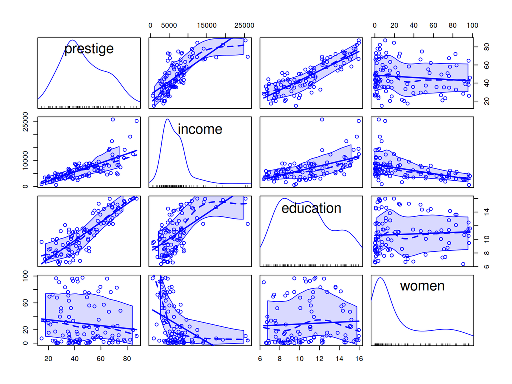

```r
scatterplotMatrix(~ prestige + income + education + women, data = Prestige)
```

También se puede ver considerando subpoblaciones (por ejemplo, de acuerdo al tipo de ocupación)

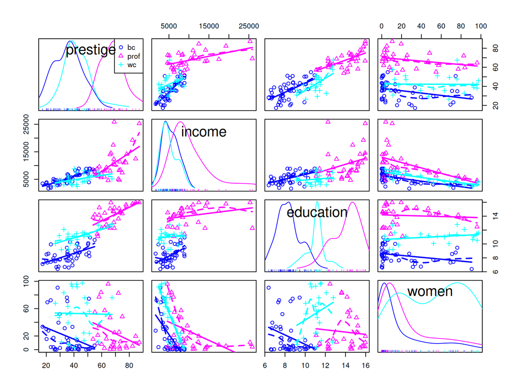

```r
scatterplotMatrix(~ prestige + income + education + women| type, data =Prestige)
```

Vemos que el ingreso tiene una distribución con colas largas. Se sugiere considerar una transformación logarítmica para tratar de normalizar los datos.

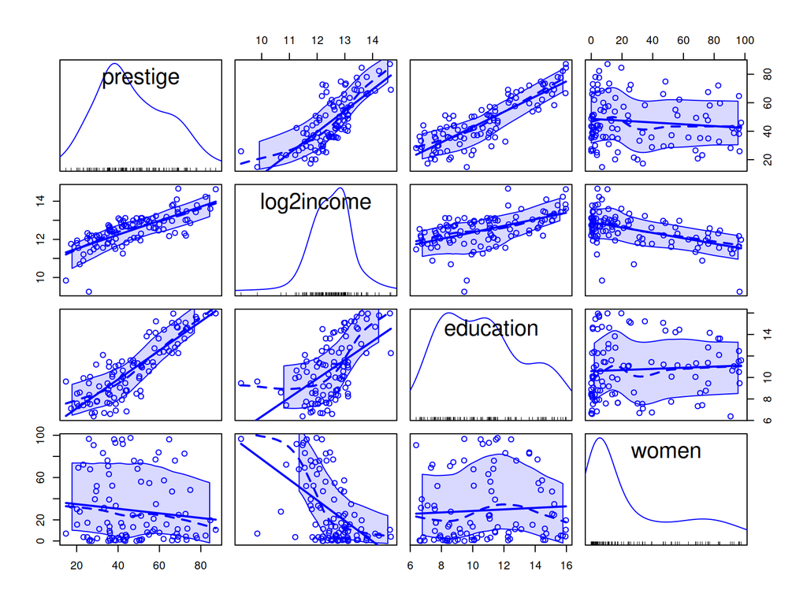

```r
# realiza la comparación de los histogramas
Prestige$log2income <- log2(Prestige$income)
scatterplotMatrix(~ prestige + log2income + education + women, data =Prestige)
```

#### Estimación

```r
(mod1 <- lm(prestige ~ education + log2income + women, data = Prestige))  # Información de los coeficientes estimados
```

```
Call:
lm(formula = prestige ~ education + log2income + women, data = Prestige)

Coefficients:
(Intercept)    education   log2income        women
  -110.9658       3.7305       9.3147       0.0469
```

```r
summary(mod1)   # Información adicional para inferencia
```

```
Call:
lm(formula = prestige ~ education + log2income + women, data = Prestige)

Residuals:
    Min      1Q  Median      3Q     Max
-17.364  -4.429  -0.101   4.316  19.179

Coefficients:
             Estimate Std. Error t value Pr(>|t|)
(Intercept) -110.9658    14.8429  -7.476 3.27e-11 ***
education      3.7305     0.3544  10.527  < 2e-16 ***
log2income     9.3147     1.3265   7.022 2.90e-10 ***
women          0.0469     0.0299   1.568     0.12
---
Signif. codes:  0 '***' 0.001 '**' 0.01 '*' 0.05 '.' 0.1 ' ' 1

Residual standard error: 7.093 on 98 degrees of freedom
Multiple R-squared:  0.8351,    Adjusted R-squared:   0.83
F-statistic: 165.4 on 3 and 98 DF,  p-value: < 2.2e-16
```

La interpretación de los coeficientes está en función de los otros regresores en el modelo. Por ejemplo:

- $\beta_1 = 3.7305$ se interpreta como, dados valores fijos de ingreso y proporción de mujeres, el incremento promedio en el prestigio de la profesión por un año adicional de educación es de 3.7 unidades de prestigio.
- $\beta_2 = 9.3147$ el incremento del $\log_2$ del ingreso en una unidad corresponde a duplicar el ingreso, así que duplicar el ingreso,manteniendo los otros predictores constantes, se asocia con un incremento en promedio de cerca de 9.3 unidades de prestigio.

### Ejemplo 2: Modelo de Análisis de varianza de una vía (One way ANOVA)

El modelo lineal más simple con factores es el modelo de ANOVA de una vía: contiene una variable factor y no tiene predictores numéricos.

En un experimento, se consideraron $n = 66$ infantes que fueron asignados aleatoriamente a uno de tres posibles grupos experimentales para enseñar lectura:

- El grupo con el método Basal (es el método estándar)
- El grupo con el método DTRA (nuevo)
- El grupo con el método Strat (nuevo)

Los investigadores consideraron dos pruebas previas al método y tres pruebas posteriores a la aplicación del método. Nos concentramos en la tercera prueba en este ejemplo.

```r
data("Baumann")
some(Baumann)  # toma una muestra de observaciones en el archivo (10 por default)
```

```
   group pretest.1 pretest.2 post.test.1 post.test.2 post.test.3
5  Basal        16         5          10           9          46
10 Basal         8         8           7           7          39
29  DRTA         9         6          10           9          49
34  DRTA         6         2           7           0          55
39  DRTA         9         5          12           6          54
41  DRTA        10         2          11           6          49
43  DRTA         8         5           8           8          49
45 Strat        11         7          11          12          53
53 Strat        13         6          12          11          49
64 Strat         8         2           9           5          33
```

Los investigadores están interesados en saber si los nuevos métodos producen mejores resultados que el método estándar y si los nuevos métodos difieren en efectividad.

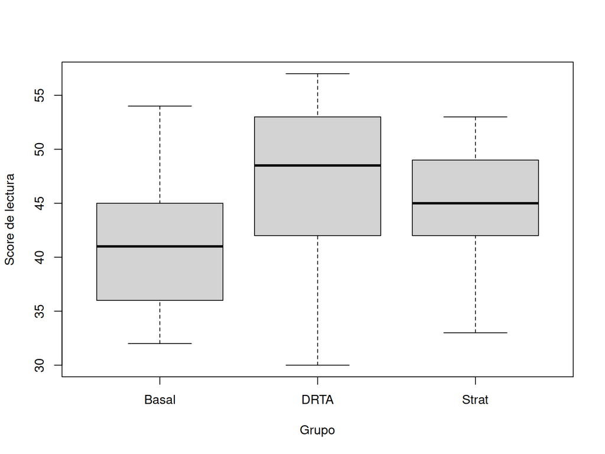

```r
boxplot(post.test.3 ~ group, data = Baumann, xlab = "Grupo", ylab = "Score de lectura")
```

Este modelo se basa prácticamente en comparar las medias de cada grupo. Lo podemos hacer vía regresión

```r
(mod2 <- lm(post.test.3 ~ group, data = Baumann))  # la variable group es un factor, y así R toma la matriz correcta
```

```
Call:
lm(formula = post.test.3 ~ group, data = Baumann)

Coefficients:
(Intercept)    groupDRTA   groupStrat
     41.045        5.682        3.227
```

```r
summary(mod2)
```

```
Call:
lm(formula = post.test.3 ~ group, data = Baumann)

Residuals:
    Min      1Q  Median      3Q     Max
-16.727  -3.614   1.114   3.954  12.954

Coefficients:
            Estimate Std. Error t value Pr(>|t|)
(Intercept)   41.045      1.346  30.490  < 2e-16 ***
groupDRTA      5.682      1.904   2.985  0.00404 **
groupStrat     3.227      1.904   1.695  0.09498 .
---
Signif. codes:  0 '***' 0.001 '**' 0.01 '*' 0.05 '.' 0.1 ' ' 1

Residual standard error: 6.314 on 63 degrees of freedom
Multiple R-squared:  0.1245,    Adjusted R-squared:  0.09675
F-statistic: 4.481 on 2 and 63 DF,  p-value: 0.01515
```

```r
X <- model.matrix(mod2)
```

### Ejemplo 3: Modelo con predictores numéricos, factores e interacciones (Modelo ANCOVA)

```r
library(alr4)
data(salary)
str(salary)
```

```
'data.frame':   52 obs. of  6 variables:
 $ degree: Factor w/ 2 levels "Masters","PhD": 1 1 1 1 2 1 2 1 2 2 ...
 $ rank  : Factor w/ 3 levels "Asst","Assoc",..: 3 3 3 3 3 3 3 3 3 3 ...
 $ sex   : Factor w/ 2 levels "Male","Female": 1 1 1 2 1 1 2 1 1 1 ...
 $ year  : int  25 13 10 7 19 16 0 16 13 13 ...
 $ ysdeg : int  35 22 23 27 30 21 32 18 30 31 ...
 $ salary: int  36350 35350 28200 26775 33696 28516 24900 31909 31850 32850 ...
```

El objetivo es entender cuál es la dependencia del salario al rango académico y la experiencia (medida por los años desde graduación) del profesor.

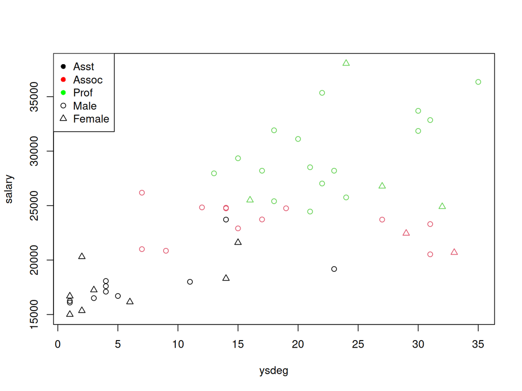

```r
with(salary, plot(ysdeg, salary, col = rank, pch = as.numeric(sex)))
with(salary, legend("topleft",
                    legend = c(levels(rank), levels(sex)),
                    col = c("black","red","green","black","black"),
                    pch = c(16,16,16,1,2)))
```

Sin considerar el sexo, hay cuatro casos a considerar:

1. Un modelo de regresión lineal simple para todos los rangos (básicamente ignorando el rango)
2. Modelo de líneas paralelas (misma pendiente, diferentes ordenadas)
3. Modelo de líneas con una ordenada al origen común (pendientes diferentes, misma interceptada)
4. Modelo de líneas diferentes para cada rango (una línea por categoría)

Cada uno de estos modelos se puede visualizar:

El primer modelo: una sola línea

```r
(m1 <- lm(salary ~ ysdeg, data = salary))
```

```
Call:
lm(formula = salary ~ ysdeg, data = salary)

Coefficients:
(Intercept)        ysdeg
    17502.3        390.6
```

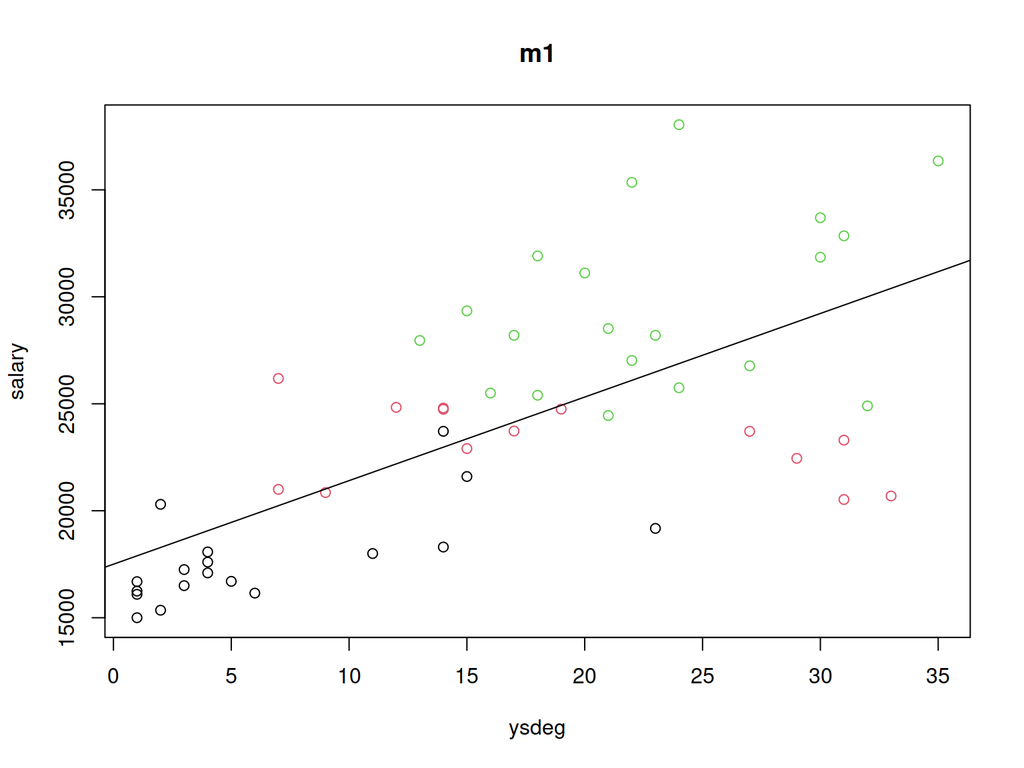

```r
with(salary, plot(ysdeg, salary, col = rank, main = "m1"))
abline(m1)
```

Modelo de líneas paralelas

```r
(m2 <- lm(salary ~ ysdeg + rank, data = salary))
```

```
Call:
lm(formula = salary ~ ysdeg + rank, data = salary)

Coefficients:
(Intercept)        ysdeg    rankAssoc     rankProf
   17166.46        95.08      4209.65     10310.30
```

```r
summary(m2)
```

```
Call:
lm(formula = salary ~ ysdeg + rank, data = salary)

Residuals:
    Min      1Q  Median      3Q     Max
-5619.5 -1494.5  -341.6  1810.3  8286.2

Coefficients:
            Estimate Std. Error t value Pr(>|t|)
(Intercept) 17166.46     785.40  21.857  < 2e-16 ***
ysdeg          95.08      58.15   1.635  0.10855
rankAssoc    4209.65    1279.20   3.291  0.00188 **
rankProf    10310.30    1359.39   7.585  9.4e-10 ***
---
Signif. codes:  0 '***' 0.001 '**' 0.01 '*' 0.05 '.' 0.1 ' ' 1

Residual standard error: 2943 on 48 degrees of freedom
Multiple R-squared:  0.7672,    Adjusted R-squared:  0.7526
F-statistic: 52.72 on 3 and 48 DF,  p-value: 3.188e-15
```

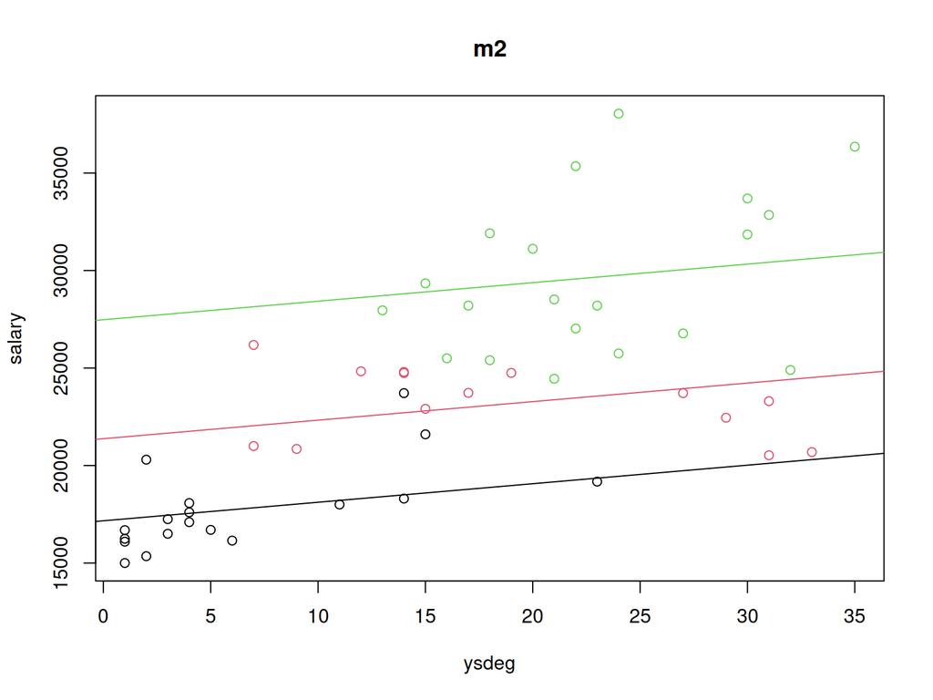

```r
with(salary, plot(ysdeg, salary, col = rank, main = "m2"))
abline(a = m2$coef[1], b = m2$coef[2])
abline(a = m2$coef[1] + m2$coef[3], b = m2$coef[2], col = 2)
abline(a = m2$coef[1] + m2$coef[4], b = m2$coef[2], col = 3)
```

Modelo de líneas con intercepción común

```r
(m3 <- lm(salary ~ ysdeg + ysdeg:rank, data=salary))
```

```
Call:
lm(formula = salary ~ ysdeg + ysdeg:rank, data = salary)

Coefficients:
    (Intercept)            ysdeg  ysdeg:rankAssoc   ysdeg:rankProf
       18834.25            22.91           150.19           433.76
```

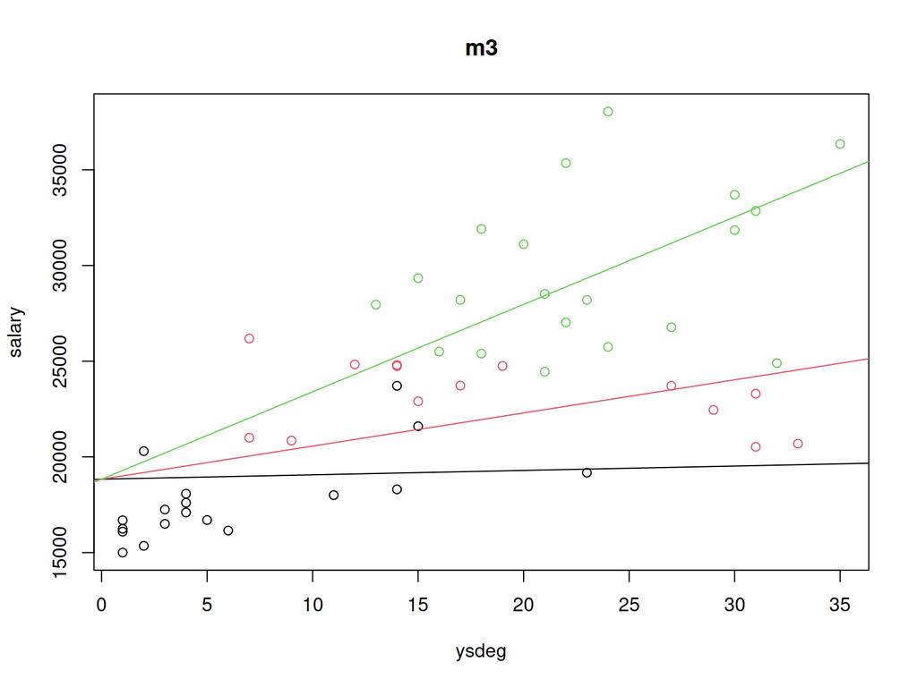

```r
with(salary, plot(ysdeg, salary, col = rank, main = "m3"))
abline(a = m3$coef[1], b = m3$coef["ysdeg"])
abline(a = m3$coef[1], b = m3$coef["ysdeg"] + m3$coef["ysdeg:rankAssoc"], col = 2)
abline(a = m3$coef[1], b = m3$coef["ysdeg"] + m3$coef["ysdeg:rankProf"], col = 3)
```

Modelo de líneas separadas. Este es el modelo más general

```r
(m4 <- lm(salary ~ ysdeg*rank, data=salary))
```

```
Call:
lm(formula = salary ~ ysdeg * rank, data = salary)

Coefficients:
    (Intercept)            ysdeg        rankAssoc         rankProf  ysdeg:rankAssoc   ysdeg:rankProf
       16345.62           224.69          8179.94          7845.14          -295.99            13.57
```

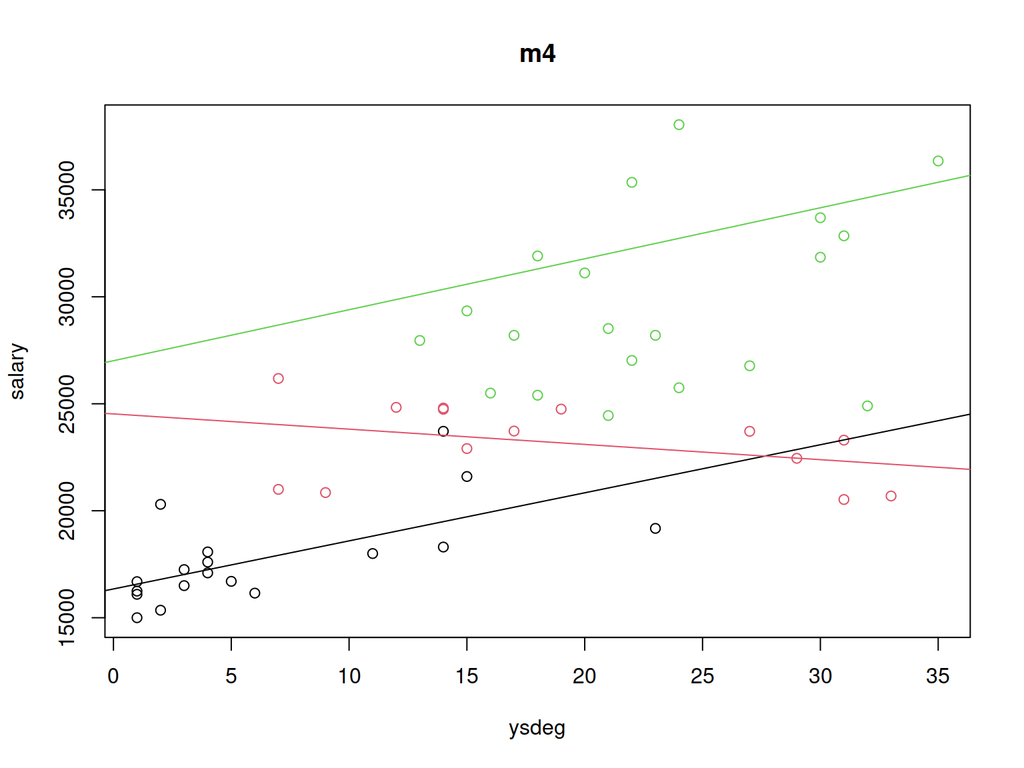

```r
with(salary,plot(ysdeg,salary,col=rank,main="m4"))
abline(a = m4$coef[1], b = m4$coef["ysdeg"])
abline(a = m4$coef[1] + m4$coef["rankAssoc"], b = m4$coef["ysdeg"] + m4$coef["ysdeg:rankAssoc"], col = 2)
abline(a = m3$coef[1] + m4$coef["rankAssoc"], b = m4$coef["ysdeg"] + m4$coef["ysdeg:rankProf"], col = 3)
```

Podemos ver que los modelos 1,2,3 son *submodelos* del caso 4. El caso 1 es un submodelo de los casos 2 y 3 y los casos 2 y 3 no están relacionados.

## Inferencia en RLM

Para ver los diferentes intervalos de confianza que se pueden obtener para los parámetros, retomamos el ejemplo 1:

La matriz de varianzas y covarianzas del estimador se puede obtener con la función `vcov`:

```r
vcov(mod1)
```

```
            (Intercept)    education   log2income        women
(Intercept) 220.3125145  2.807569475 -19.30890049 -0.300651815
education     2.8075695  0.125587340  -0.32063628 -0.005174436
log2income  -19.3089005 -0.320636282   1.75964236  0.026436454
women        -0.3006518 -0.005174436   0.02643645  0.000893942
```

Tomamos de esta matriz lo que necesitemos para los diferentes intervalos

### Región de confianza de $\beta_1$y $\beta_2$

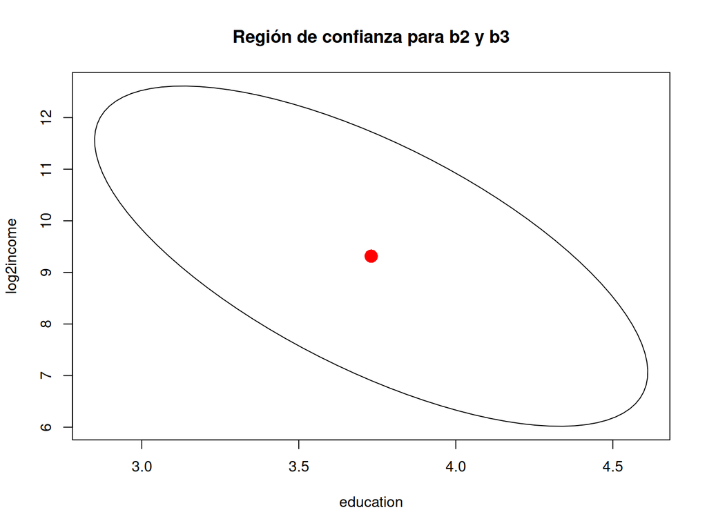

```r
library(ellipse)
plot(ellipse(mod1, which = c(2,3), level = 0.95), type = "l",
     main = "Región de confianza para b2 y b3")
points(mod1$coef[2], mod1$coef[3], pch = 16, col = "red", cex = 2)
```

```r
n <- nrow(Prestige)
alfa <- 0.05
k <- 4
p <- 3
interv_marg <- matrix(numeric(), nrow = k, ncol = 2)  # para guardar los números

for(i in 1:k) interv_marg[i,] <- mod1$coef[i] + c(-1,1)*pt(n-k,alfa/2, lower.tail = F)*sqrt(diag(vcov(mod1))[i])
# Crea una tabla con los resultados
a <- cbind(mod1$coef, interv_marg)  # incluye el vector de valores estimados
colnames(a) <- c("betahat","lim_inf","lim_sup")
a
```

```
                  betahat       lim_inf       lim_sup
(Intercept) -110.96582409 -117.17833339 -104.75331479
education      3.73050783    3.58218076    3.87883489
log2income     9.31466643    8.75945337    9.86987949
women          0.04689514    0.03438096    0.05940931
```

### Intervalos simultáneos

```r
interv_simul <- matrix(numeric(), nrow = k, ncol =2)
for(i in 1:k) interv_simul[i,] <- mod1$coef[i] + c(-1,1)*sqrt(pf(k,n-k,alfa, lower.tail = F))*sqrt(diag(vcov(mod1))[i])
b <- cbind(mod1$coef, interv_simul)  # incluye el vector de valores estimados
colnames(b) <- c("betahat","lim_inf","lim_sup")
b
```

```
                  betahat       lim_inf      lim_sup
(Intercept) -110.96582409 -124.99086271 -96.94078547
education      3.73050783    3.39565235   4.06536331
log2income     9.31466643    8.06124624  10.56808662
women          0.04689514    0.01864379   0.07514649
```

Los intervalos simultáneos siempre son más anchos, porque toman en cuenta la variabilidad conjunta.